# research_method_2_final

2023-06-05

# 1. 区間推定

次の図はR で行った区間推定の命令と実行結果です。この分析結果を解釈 して下さい。

パッケージの用意

```r
install.packages("dplyr",dep=T,repos = "http://cran.us.r-project.org") # 一度もインストールしていない場合
```

```r
install.packages("ggplot2",dep=T,repos = "http://cran.us.r-project.org") # 一度もインストールしていない場合
library(dplyr)
library(ggplot2)
```

### データの用意

```r
set.seed(100)
data <- rnorm(10, 14.8, 1.2) %>% round()
library(BSDA)
z.test(x=data, y = NULL, alternative = "two.sided", mu = 0, sigma.x = 1.2, sigma.y = NULL, conf.level = 0.95)
```

```
##
##  One-sample z-Test
##
## data:  data
## z = 39.001, p-value < 2.2e-16
## alternative hypothesis: true mean is not equal to 0
## 95 percent confidence interval:
##  14.05625 15.54375
## sample estimates:
## mean of x
##      14.8
```

```r
#xは信頼区間を求めるデータを指定。yはこの場合、NULL(指定なし)。alternative="two.sided"は両側検定, mu=0は帰無仮説と平均値が違う場合に指定。sigma.xは母集団の標準偏差, sigma.yもデータがある場合は同様。conf.levelは指定したい信頼区間。
```

### 解釈例

平均14.8, 標準偏差1.2の標準正規分布に従う値10個の乱数を発生させ、round()で整数値にして、変数「data」に格納している。 dataについて、平均値0とdataの平均値14.8の間で差があるかどうかを有意水準5%で両側検定している。 (dataに対して母平均が0と異なるかどうかを検定している。) 帰無仮説：母平均0。 対立仮説：母平均が0と異なる。 検定の結果を読み取ると、p-value < 2.2e-16<0.05なので、有意水準5%で帰無仮説を棄却する。よって、母平均は0ではない。 区間推定の結果を読み取ると、信頼係数95%で、母平均は14.06以上15.54以下の範囲に収まる。 ちなみに、標本から得られる標本平均は14.8。

# 2. 分散分析

次の図はR で行った分散分析の結果です。この分析結果を解釈して下さい。

**データの説明** データセットPlantGrowthは栽培条件の異なる植物の成長記録です。c(1:3,11:13,21:23)は変数groupから一部を取り出したものです。groupは３種類の栽培条件”ctr1”,“trt1”,“trt2”の区別を表し、weightには、その条件で栽培された植物の個体ごとに重量が記録されています。

```r
# データの作成
data(PlantGrowth)
PlantGrowth[c(1:3, 11:13, 21:23),]
```

```
##    weight group
## 1    4.17  ctrl
## 2    5.58  ctrl
## 3    5.18  ctrl
## 11   4.81  trt1
## 12   4.17  trt1
## 13   4.41  trt1
## 21   6.31  trt2
## 22   5.12  trt2
## 23   5.54  trt2
```

```r
PGaov <- aov(weight ~ group, data=PlantGrowth)
```

```r
summary(PGaov)
```

```
##             Df Sum Sq Mean Sq F value Pr(>F)
## group        2  3.766  1.8832   4.846 0.0159 *
## Residuals   27 10.492  0.3886
## ---
## Signif. codes:  0 '***' 0.001 '**' 0.01 '*' 0.05 '.' 0.1 ' ' 1
```

帰無仮説：３種類の栽培条件に差がない。

対立仮説：３種類の栽培条件に差がある。

である。 Pr(>F) = 0.0159 *となっており、有意水準5%とすれば、 Pr(>F) = 0.0159 < 0.05であるため、帰無仮説を棄却する。

このため、対立仮説である3種類の栽培条件に差があるを採択する。

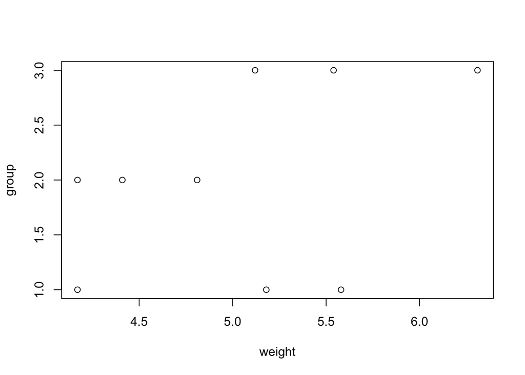

```r
plot(PlantGrowth[c(1:3, 11:13, 21:23),])
```

散布図を書いても何となく傾向が見える。

# 3. 重回帰分析

次の図はR で行った重回帰分析の結果です。この分析結果を解釈して下さい。

**データの説明**

データセットmtcarsは、1974年のモデルの車両に関する性能や特徴を含んでいます。

次は変数の説明です。

[, 1] mpg Miles/(US) gallon

[, 3] disp Displacement (cu.in.)

[, 4] hp Gross horsepower

[, 6] wt Weight (1000 lbs)

```r
# mtcarsデータセットの読み込み
data(mtcars)

# 重回帰分析を実行
model <- lm(mpg ~ wt + hp + disp, data = mtcars)

# 分析結果の要約表示
summary(model)
```

```
##
## Call:
## lm(formula = mpg ~ wt + hp + disp, data = mtcars)
##
## Residuals:
##    Min     1Q Median     3Q    Max
## -3.891 -1.640 -0.172  1.061  5.861
##
## Coefficients:
##              Estimate Std. Error t value Pr(>|t|)
## (Intercept) 37.105505   2.110815  17.579  < 2e-16 ***
## wt          -3.800891   1.066191  -3.565  0.00133 **
## hp          -0.031157   0.011436  -2.724  0.01097 *
## disp        -0.000937   0.010350  -0.091  0.92851
## ---
## Signif. codes:  0 '***' 0.001 '**' 0.01 '*' 0.05 '.' 0.1 ' ' 1
##
## Residual standard error: 2.639 on 28 degrees of freedom
## Multiple R-squared:  0.8268, Adjusted R-squared:  0.8083
## F-statistic: 44.57 on 3 and 28 DF,  p-value: 8.65e-11
```

1. 燃費mpg = 重量wt + 馬力hp + 排気量dispで説明しようとした場合、結果を見ると、有意水準5%でp=0.92851>0.05となるため、帰無仮説「係数は0である」を棄却できない。このため、変数dispを説明変数として入れるのは適切ではない可能性が高い。

決定係数も調整済み決定係数も0.8を超えており、この回帰式の説明力は高いと言える。

F統計量の部分は、帰無仮説「決定係数が0である」を分散分析の手法で検定している。p-value:8.65e-11なので、帰無仮説を5%有意水準においても、それ以下の水準においても棄却できる。このため、上記の決定係数には意味があるといえる。

ただし、この回帰式においては1点問題があり、それは説明変数としてdispを入れた点である。

#### 相関係数を求め散布図を描く

```r
cor(mtcars)
```

```
##             mpg        cyl       disp         hp        drat         wt
## mpg   1.0000000 -0.8521620 -0.8475514 -0.7761684  0.68117191 -0.8676594
## cyl  -0.8521620  1.0000000  0.9020329  0.8324475 -0.69993811  0.7824958
## disp -0.8475514  0.9020329  1.0000000  0.7909486 -0.71021393  0.8879799
## hp   -0.7761684  0.8324475  0.7909486  1.0000000 -0.44875912  0.6587479
## drat  0.6811719 -0.6999381 -0.7102139 -0.4487591  1.00000000 -0.7124406
## wt   -0.8676594  0.7824958  0.8879799  0.6587479 -0.71244065  1.0000000
## qsec  0.4186840 -0.5912421 -0.4336979 -0.7082234  0.09120476 -0.1747159
## vs    0.6640389 -0.8108118 -0.7104159 -0.7230967  0.44027846 -0.5549157
## am    0.5998324 -0.5226070 -0.5912270 -0.2432043  0.71271113 -0.6924953
## gear  0.4802848 -0.4926866 -0.5555692 -0.1257043  0.69961013 -0.5832870
## carb -0.5509251  0.5269883  0.3949769  0.7498125 -0.09078980  0.4276059
##             qsec         vs          am       gear        carb
## mpg   0.41868403  0.6640389  0.59983243  0.4802848 -0.55092507
## cyl  -0.59124207 -0.8108118 -0.52260705 -0.4926866  0.52698829
## disp -0.43369788 -0.7104159 -0.59122704 -0.5555692  0.39497686
## hp   -0.70822339 -0.7230967 -0.24320426 -0.1257043  0.74981247
## drat  0.09120476  0.4402785  0.71271113  0.6996101 -0.09078980
## wt   -0.17471588 -0.5549157 -0.69249526 -0.5832870  0.42760594
## qsec  1.00000000  0.7445354 -0.22986086 -0.2126822 -0.65624923
## vs    0.74453544  1.0000000  0.16834512  0.2060233 -0.56960714
## am   -0.22986086  0.1683451  1.00000000  0.7940588  0.05753435
## gear -0.21268223  0.2060233  0.79405876  1.0000000  0.27407284
## carb -0.65624923 -0.5696071  0.05753435  0.2740728  1.00000000
```

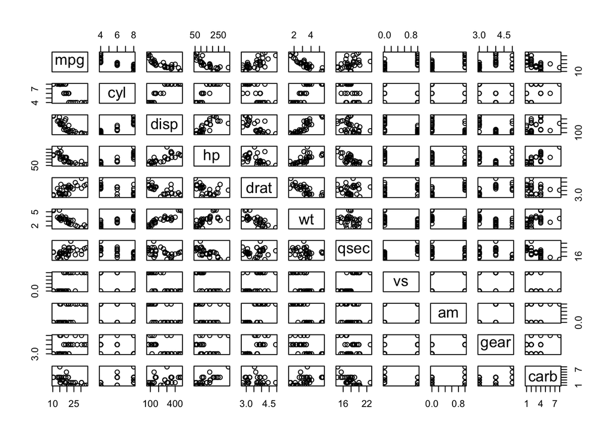

```r
pairs(mtcars) #全部
```

#### 変数選択を行うと適切な変数を選択することが可能。

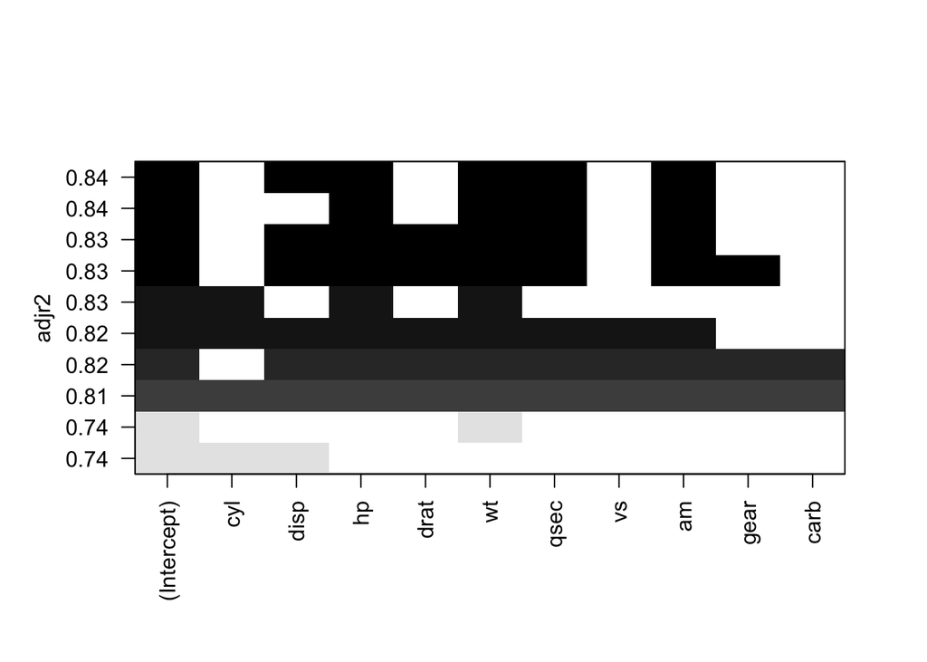

```r
library(leaps)
best<-regsubsets(mpg~., data = mtcars, nvmax = 10, method = "seqrep")
sbest<-summary(best)
plot(best,scale="adjr2")
```

```r
sbest$rss #これらのモデルのRSS(残差変動)
```

```
##  [1] 278.3219 270.7403 176.6205 160.0665 153.4378 150.0933 148.5283 148.8728
##  [9] 147.5743 147.4944
```

```r
n<-ncol(mtcars) #Bostonの変数の数をnとする
p<-nrow(sbest$which) #ベストモデルsbestの数
aicbest<- n*(1+log(2*pi*sbest$rss/n))+2*(2+(1:p)) #各モデルのAICの計算
aicbest #AICの表示
```

```
##  [1] 72.75636 74.45256 71.75384 72.67128 74.20605 75.96362 77.84833 79.87382
##  [9] 81.77745 83.77149
```

```r
order(aicbest) #AICの小さい順に並べると3番目のモデルが最小
```

```
##  [1]  3  4  1  5  2  6  7  8  9 10
```

```r
sbest$which[3,] #3番目のモデルの変数の有無を表示。TRUEが採用する変数。
```

```
## (Intercept)         cyl        disp          hp        drat          wt
##        TRUE        TRUE       FALSE        TRUE       FALSE        TRUE
##        qsec          vs          am        gear        carb
##       FALSE       FALSE       FALSE       FALSE       FALSE
```

```r
aicbest[3] #3番目のモデルのAIC
```

```
## [1] 71.75384
```

```r
sbest$which[4,] #4番目のモデルの変数の有無を表示。TRUEが採用する変数。
```

```
## (Intercept)         cyl        disp          hp        drat          wt
##        TRUE       FALSE       FALSE        TRUE       FALSE        TRUE
##        qsec          vs          am        gear        carb
##        TRUE       FALSE        TRUE       FALSE       FALSE
```

```r
aicbest[4]
```

```
## [1] 72.67128
```

```r
sbest$which[1,] #1番目のモデルの変数の有無を表示。TRUEが採用する変数。
```

```
## (Intercept)         cyl        disp          hp        drat          wt
##        TRUE       FALSE       FALSE       FALSE       FALSE        TRUE
##        qsec          vs          am        gear        carb
##       FALSE       FALSE       FALSE       FALSE       FALSE
```

```r
aicbest[1]
```

```
## [1] 72.75636
```

cyl, hp, wtで回帰がベスト

```r
# 重回帰分析を実行
model2 <- lm(mpg ~ wt + hp + cyl, data = mtcars)

# 分析結果の要約表示
summary(model2)
```

```
##
## Call:
## lm(formula = mpg ~ wt + hp + cyl, data = mtcars)
##
## Residuals:
##     Min      1Q  Median      3Q     Max
## -3.9290 -1.5598 -0.5311  1.1850  5.8986
##
## Coefficients:
##             Estimate Std. Error t value Pr(>|t|)
## (Intercept) 38.75179    1.78686  21.687  < 2e-16 ***
## wt          -3.16697    0.74058  -4.276 0.000199 ***
## hp          -0.01804    0.01188  -1.519 0.140015
## cyl         -0.94162    0.55092  -1.709 0.098480 .
## ---
## Signif. codes:  0 '***' 0.001 '**' 0.01 '*' 0.05 '.' 0.1 ' ' 1
##
## Residual standard error: 2.512 on 28 degrees of freedom
## Multiple R-squared:  0.8431, Adjusted R-squared:  0.8263
## F-statistic: 50.17 on 3 and 28 DF,  p-value: 2.184e-11
```

```r
AIC(model)
```

```
## [1] 158.643
```

```r
AIC(model2)
```

```
## [1] 155.4766
```

[, 1] mpg Miles/(US) gallon 燃費 [, 3] disp Displacement (cu.in.) 排気量 [, 4] hp Gross horsepower 馬力 [, 6] wt Weight (1000 lbs) 重量

1. 燃費mpg=重量wt + 馬力hp + 排気量disp で説明しようとした場合と、
2. 燃費=重量wt + 馬力hp + シリンダーの数cyl

では、2の方がAICが低いので説明力がある。 ただし、まだhpのp値が有意水準5%の条件を満たしていない。

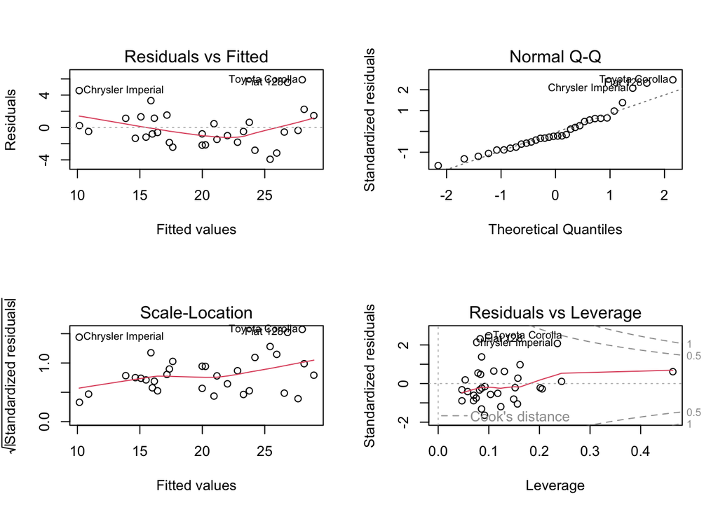

```r
#回帰診断
par(mfrow=c(2,2))
plot(model2)
```

多少外れ値がある模様。外れ値は

[1] “Toyota Corolla”

[1] “Fiat 128”

[1] “Chrysler Imperial”

```r
order(model2$residuals,decreasing = T) #残差の大きい方から並び替える。
```

```
##  [1] 20 18 17 25 28  5 19 12 13 31  8  4 16 26 15  9 27 29 10 14  2  7 24 30  1
## [26] 22  6 11 23 32  3 21
```

```r
rownames(mtcars[20,]) #残差最大
```

```
## [1] "Toyota Corolla"
```

```r
rownames(mtcars[18,]) #残差2番目
```

```
## [1] "Fiat 128"
```

```r
rownames(mtcars[17,]) #残差3番目
```

```
## [1] "Chrysler Imperial"
```

```r
mtcars2<-mtcars[-c(20,18,17),] #該当の行を抜く
```

```r
model3 <- lm(mpg ~ wt + hp + cyl, data = mtcars2)
summary(model3)
```

```
##
## Call:
## lm(formula = mpg ~ wt + hp + cyl, data = mtcars2)
##
## Residuals:
##     Min      1Q  Median      3Q     Max
## -2.8658 -1.3416 -0.0721  1.1467  3.5009
##
## Coefficients:
##              Estimate Std. Error t value Pr(>|t|)
## (Intercept) 37.125506   1.355432  27.390  < 2e-16 ***
## wt          -3.465955   0.573558  -6.043 2.59e-06 ***
## hp          -0.017494   0.008368  -2.091   0.0469 *
## cyl         -0.629801   0.396150  -1.590   0.1244
## ---
## Signif. codes:  0 '***' 0.001 '**' 0.01 '*' 0.05 '.' 0.1 ' ' 1
##
## Residual standard error: 1.748 on 25 degrees of freedom
## Multiple R-squared:  0.8967, Adjusted R-squared:  0.8843
## F-statistic: 72.37 on 3 and 25 DF,  p-value: 1.845e-12
```

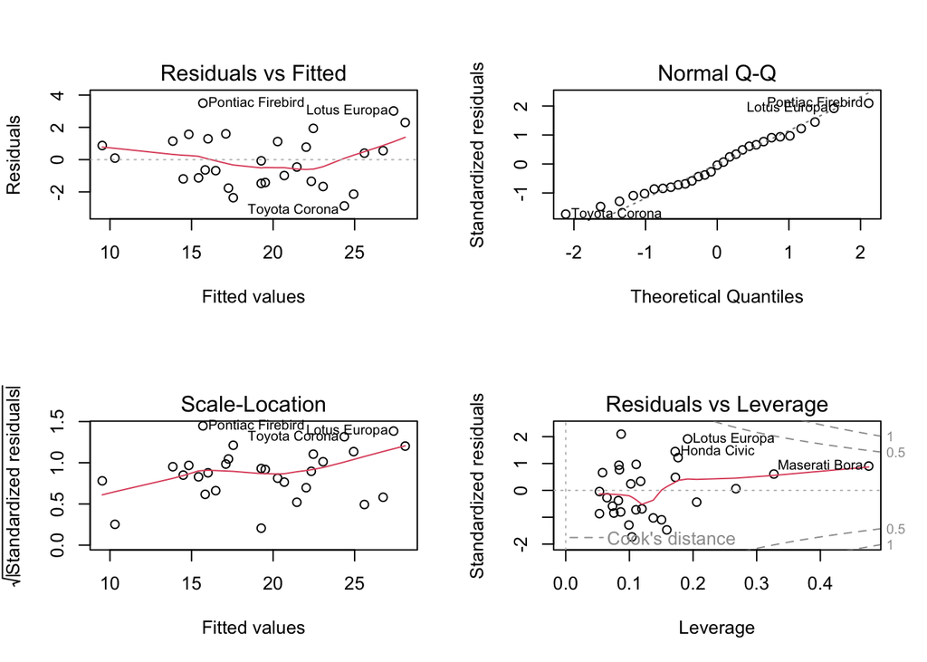

```r
par(mfrow=c(2,2))
plot(model3)
```

```r
AIC(model2)
```

```
## [1] 155.4766
```

```r
AIC(model3)
```

```
## [1] 120.3939
```

外れ値を抜いたmodel3では、今度はcylのp値が有意水準を上回ってしまった。しかし、AICはmodel3の方が低くなっている。 2. 燃費=重量wt + 馬力hp + シリンダーの数cyl であり、車によって微妙に馬力とシリンダーの燃費への関わり方が違ってきているのかもしれない。 できるだけデータは削除したくないので、model2について詳細をこれ以後見ていく。

#### 多重共線性の評価

```r
library(car)
vif(model2)
```

```
##       wt       hp      cyl
## 2.580486 3.258481 4.757456
```

```r
vif(model3)
```

```
##       wt       hp      cyl
## 2.389839 2.872765 4.405194
```

多重共線性は何の変数もvif=10以下なのでクリア。

```r
z = as.data.frame( scale(mtcars) ) #scale関数で各列の値は平均0、標準偏差1の分布となる
zfit = lm( mpg ~ wt + hp + cyl, data = z )
options( scipen = 20 ) #表示される数値の指数表記の桁数（表示精度）を設定
summary( zfit )
```

```
##
## Call:
## lm(formula = mpg ~ wt + hp + cyl, data = z)
##
## Residuals:
##      Min       1Q   Median       3Q      Max
## -0.65191 -0.25880 -0.08813  0.19662  0.97870
##
## Coefficients:
##                           Estimate             Std. Error t value Pr(>|t|)
## (Intercept)  0.0000000000000008628  0.0736663457052350867   0.000 1.000000
## wt          -0.5141488503266713472  0.1202303346412717938  -4.276 0.000199 ***
## hp          -0.2052023701458776661  0.1351048252147987738  -1.519 0.140015
## cyl         -0.2790224559974667784  0.1632490412704540317  -1.709 0.098480 .
## ---
## Signif. codes:  0 '***' 0.001 '**' 0.01 '*' 0.05 '.' 0.1 ' ' 1
##
## Residual standard error: 0.4167 on 28 degrees of freedom
## Multiple R-squared:  0.8431, Adjusted R-squared:  0.8263
## F-statistic: 50.17 on 3 and 28 DF,  p-value: 0.00000000002184
```